# Linear Model LM - part I

Edwin Lo, GWU Intro to Data Science DATS 6101

2022-03-19

```r
loadPkg("ggplot2")
```

# Regression

## Faraway::stat500 Dataset

Let us run some simple linear model:

```r
#For this example we are going to use data from the faraway library from the package with the same name.
loadPkg("faraway")
#The data set is stat500, so let's take a look
str(stat500)
```

```
## 'data.frame':    55 obs. of  4 variables:
##  $ midterm: num  24.5 22.5 23.5 23.5 22.5 16 27.5 22.5 25 30 ...
##  $ final  : num  26 24.5 26.5 34.5 30.5 31 33.5 31 29.5 37.5 ...
##  $ hw     : num  28.5 28.2 28.3 29.2 27.3 27.5 29.7 29 27.3 27.2 ...
##  $ total  : num  79 75.2 78.3 87.2 80.3 74.5 90.7 82.5 81.8 94.7 ...
```

```r
#Determine whether midterm and homework grades predict the final
model.final <- lm(final~midterm+hw,data=stat500)
summary(model.final)
```

```
##
## Call:
## lm(formula = final ~ midterm + hw, data = stat500)
##
## Residuals:
##     Min      1Q  Median      3Q     Max
## -10.039  -2.596   0.371   3.006   9.350
##
## Coefficients:
##             Estimate Std. Error t value Pr(>|t|)
## (Intercept)  16.8106     4.0811    4.12  0.00014 ***
## midterm       0.5818     0.1244    4.67  2.1e-05 ***
## hw           -0.0816     0.1492   -0.55  0.58684
## ---
## Signif. codes:  0 '***' 0.001 '**' 0.01 '*' 0.05 '.' 0.1 ' ' 1
##
## Residual standard error: 4.22 on 52 degrees of freedom
## Multiple R-squared:  0.301,  Adjusted R-squared:  0.274
## F-statistic: 11.2 on 2 and 52 DF,  p-value: 8.95e-05
```

The code above does not output to html by our choice. To display the model summary, we’ll use the function `ezids::xkabledply( )`. The function can also take a generic table and display it, as you can see from the definition/help menu.

```r
xkabledply(model.final, title = "stat500 Model summary: final~midterm+hw")
```

stat500 Model summary: final~midterm+hw

|  | Estimate | Std. Error | t value | Pr(>\|t\|) |
| --- | --- | --- | --- | --- |
| (Intercept) | 16.8106 | 4.081 | 4.119 | 0.0001 |
| midterm | 0.5818 | 0.124 | 4.675 | 0.0000 |
| hw | -0.0816 | 0.149 | -0.547 | 0.5868 |

From looking at the parts (attributes) in the model object `model.final`, we can pull out different parts if needed. For example, the basic display of some of the info is given here (hidden in html output).

```r
model.final$coefficients
```

```
## (Intercept)     midterm          hw
##     16.8106      0.5818     -0.0816
```

```r
model.final$call
```

```
## lm(formula = final ~ midterm + hw, data = stat500)
```

```r
model.final$model$final
```

```
##  [1] 26.0 24.5 26.5 34.5 30.5 31.0 33.5 31.0 29.5 37.5 19.5 23.5 21.0 20.0 15.5
## [16] 20.0 31.0 23.5 22.0 30.5 28.5 23.0 32.5 26.5 28.5 30.5 21.0 25.5 23.0 28.5
## [31] 29.0 27.0 19.5 27.5 24.0 27.0 32.5 22.0 29.5 32.5 23.5 28.5 24.5 26.0 23.0
## [46] 30.0 13.0 19.5 32.5 30.0 27.0 26.5 23.0 33.0 28.0
```

The first model call is lm(formula = final ~ midterm + hw, data = stat500).

The coefficients and the p-values are found to be  
intercept: 16.8 (p: 0.000137)  
midterm: 0.582 (p: 2.12e-05)  
hw: -0.0816 (p: 0.587).  
The adjusted r<sup>2</sup> of the model is 0.274.

Notice that in the RMD inline codes above, the coefficients are part of the attributes of the model object `model.final`. But the p-values are not stored directly in that object. Rather it is calculated by the standard `summary( )` function, which results in a complicated summary-object. The p-values are part of this summary-object. Similarly, the r<sup>2</sup> value of the model is not stored directly in the model object, but in the summary-object.

So find out more about how the model-object and the model-summary-object are structured, we can inspect them from the environment pane, or we can use the basic function `str( )`. (Not shown in html. Run codes locally to see the results.)

```r
str(model.final)
```

```
## List of 12
##  $ coefficients : Named num [1:3] 16.8106 0.5818 -0.0816
##   ..- attr(*, "names")= chr [1:3] "(Intercept)" "midterm" "hw"
##  $ residuals    : Named num [1:55] -2.74 -3.1 -1.67 6.4 2.83 ...
##   ..- attr(*, "names")= chr [1:55] "1" "2" "3" "4" ...
##  $ effects      : Named num [1:55] -196.46 -19.85 2.31 7 3.29 ...
##   ..- attr(*, "names")= chr [1:55] "(Intercept)" "midterm" "hw" "" ...
##  $ rank         : int 3
##  $ fitted.values: Named num [1:55] 28.7 27.6 28.2 28.1 27.7 ...
##   ..- attr(*, "names")= chr [1:55] "1" "2" "3" "4" ...
##  $ assign       : int [1:3] 0 1 2
##  $ qr           :List of 5
##   ..$ qr   : num [1:55, 1:3] -7.416 0.135 0.135 0.135 0.135 ...
##   .. ..- attr(*, "dimnames")=List of 2
##   .. .. ..$ : chr [1:55] "1" "2" "3" "4" ...
##   .. .. ..$ : chr [1:3] "(Intercept)" "midterm" "hw"
##   .. ..- attr(*, "assign")= int [1:3] 0 1 2
##   ..$ qraux: num [1:3] 1.13 1.05 1.04
##   ..$ pivot: int [1:3] 1 2 3
##   ..$ tol  : num 1e-07
##   ..$ rank : int 3
##   ..- attr(*, "class")= chr "qr"
##  $ df.residual  : int 52
##  $ xlevels      : Named list()
##  $ call         : language lm(formula = final ~ midterm + hw, data = stat500)
##  $ terms        :Classes 'terms', 'formula'  language final ~ midterm + hw
##   .. ..- attr(*, "variables")= language list(final, midterm, hw)
##   .. ..- attr(*, "factors")= int [1:3, 1:2] 0 1 0 0 0 1
##   .. .. ..- attr(*, "dimnames")=List of 2
##   .. .. .. ..$ : chr [1:3] "final" "midterm" "hw"
##   .. .. .. ..$ : chr [1:2] "midterm" "hw"
##   .. ..- attr(*, "term.labels")= chr [1:2] "midterm" "hw"
##   .. ..- attr(*, "order")= int [1:2] 1 1
##   .. ..- attr(*, "intercept")= int 1
##   .. ..- attr(*, "response")= int 1
##   .. ..- attr(*, ".Environment")=<environment: R_GlobalEnv>
##   .. ..- attr(*, "predvars")= language list(final, midterm, hw)
##   .. ..- attr(*, "dataClasses")= Named chr [1:3] "numeric" "numeric" "numeric"
##   .. .. ..- attr(*, "names")= chr [1:3] "final" "midterm" "hw"
##  $ model        :'data.frame':   55 obs. of  3 variables:
##   ..$ final  : num [1:55] 26 24.5 26.5 34.5 30.5 31 33.5 31 29.5 37.5 ...
##   ..$ midterm: num [1:55] 24.5 22.5 23.5 23.5 22.5 16 27.5 22.5 25 30 ...
##   ..$ hw     : num [1:55] 28.5 28.2 28.3 29.2 27.3 27.5 29.7 29 27.3 27.2 ...
##   ..- attr(*, "terms")=Classes 'terms', 'formula'  language final ~ midterm + hw
##   .. .. ..- attr(*, "variables")= language list(final, midterm, hw)
##   .. .. ..- attr(*, "factors")= int [1:3, 1:2] 0 1 0 0 0 1
##   .. .. .. ..- attr(*, "dimnames")=List of 2
##   .. .. .. .. ..$ : chr [1:3] "final" "midterm" "hw"
##   .. .. .. .. ..$ : chr [1:2] "midterm" "hw"
##   .. .. ..- attr(*, "term.labels")= chr [1:2] "midterm" "hw"
##   .. .. ..- attr(*, "order")= int [1:2] 1 1
##   .. .. ..- attr(*, "intercept")= int 1
##   .. .. ..- attr(*, "response")= int 1
##   .. .. ..- attr(*, ".Environment")=<environment: R_GlobalEnv>
##   .. .. ..- attr(*, "predvars")= language list(final, midterm, hw)
##   .. .. ..- attr(*, "dataClasses")= Named chr [1:3] "numeric" "numeric" "numeric"
##   .. .. .. ..- attr(*, "names")= chr [1:3] "final" "midterm" "hw"
##  - attr(*, "class")= chr "lm"
```

```r
str(summary(model.final))
```

```
## List of 11
##  $ call         : language lm(formula = final ~ midterm + hw, data = stat500)
##  $ terms        :Classes 'terms', 'formula'  language final ~ midterm + hw
##   .. ..- attr(*, "variables")= language list(final, midterm, hw)
##   .. ..- attr(*, "factors")= int [1:3, 1:2] 0 1 0 0 0 1
##   .. .. ..- attr(*, "dimnames")=List of 2
##   .. .. .. ..$ : chr [1:3] "final" "midterm" "hw"
##   .. .. .. ..$ : chr [1:2] "midterm" "hw"
##   .. ..- attr(*, "term.labels")= chr [1:2] "midterm" "hw"
##   .. ..- attr(*, "order")= int [1:2] 1 1
##   .. ..- attr(*, "intercept")= int 1
##   .. ..- attr(*, "response")= int 1
##   .. ..- attr(*, ".Environment")=<environment: R_GlobalEnv>
##   .. ..- attr(*, "predvars")= language list(final, midterm, hw)
##   .. ..- attr(*, "dataClasses")= Named chr [1:3] "numeric" "numeric" "numeric"
##   .. .. ..- attr(*, "names")= chr [1:3] "final" "midterm" "hw"
##  $ residuals    : Named num [1:55] -2.74 -3.1 -1.67 6.4 2.83 ...
##   ..- attr(*, "names")= chr [1:55] "1" "2" "3" "4" ...
##  $ coefficients : num [1:3, 1:4] 16.8106 0.5818 -0.0816 4.0811 0.1244 ...
##   ..- attr(*, "dimnames")=List of 2
##   .. ..$ : chr [1:3] "(Intercept)" "midterm" "hw"
##   .. ..$ : chr [1:4] "Estimate" "Std. Error" "t value" "Pr(>|t|)"
##  $ aliased      : Named logi [1:3] FALSE FALSE FALSE
##   ..- attr(*, "names")= chr [1:3] "(Intercept)" "midterm" "hw"
##  $ sigma        : num 4.22
##  $ df           : int [1:3] 3 52 3
##  $ r.squared    : num 0.301
##  $ adj.r.squared: num 0.274
##  $ fstatistic   : Named num [1:3] 11.2 2 52
##   ..- attr(*, "names")= chr [1:3] "value" "numdf" "dendf"
##  $ cov.unscaled : num [1:3, 1:3] 0.93534 -0.01023 -0.02703 -0.01023 0.00087 ...
##   ..- attr(*, "dimnames")=List of 2
##   .. ..$ : chr [1:3] "(Intercept)" "midterm" "hw"
##   .. ..$ : chr [1:3] "(Intercept)" "midterm" "hw"
##  - attr(*, "class")= chr "summary.lm"
```

There are other higher level functions such as `stat::coef( )` and `stat::confint( )`, which takes the info from a model-object and extract out important and helpful information.

```r
coef(model.final)
```

```
## (Intercept)     midterm          hw
##     16.8106      0.5818     -0.0816
```

```r
# equivalent to
# model.final$coefficients

confint(model.final)
```

```
##              2.5 % 97.5 %
## (Intercept)  8.621 25.000
## midterm      0.332  0.832
## hw          -0.381  0.218
```

We can use these inline like these:  
The coefficients and the p-values are found to be  
intercept: 16.811 (interval: [ 8.62, 25.00])  
midterm: 0.582 (interval: [0.332, 0.832])  
hw: -0.082 (interval: [-0.381, 0.218]).

### Effect of scaling on LM

Negative. Let us try scale up/down the numerical values of the predictors. (Again, results not shown in html. Run codes locally to see result.)

```r
stat500s = stat500
stat500s$midterm = stat500$midterm * 1000000
stat500s$hw = stat500$hw / 1000000
#Determine whether midterm and homework grades predict the final
modelscaled.final <- lm(final~midterm+hw,data=stat500s)
summary(modelscaled.final)
```

```
##
## Call:
## lm(formula = final ~ midterm + hw, data = stat500s)
##
## Residuals:
##     Min      1Q  Median      3Q     Max
## -10.039  -2.596   0.371   3.006   9.350
##
## Coefficients:
##              Estimate Std. Error t value Pr(>|t|)
## (Intercept)  1.68e+01   4.08e+00    4.12  0.00014 ***
## midterm      5.82e-07   1.24e-07    4.67  2.1e-05 ***
## hw          -8.16e+04   1.49e+05   -0.55  0.58684
## ---
## Signif. codes:  0 '***' 0.001 '**' 0.01 '*' 0.05 '.' 0.1 ' ' 1
##
## Residual standard error: 4.22 on 52 degrees of freedom
## Multiple R-squared:  0.301,  Adjusted R-squared:  0.274
## F-statistic: 11.2 on 2 and 52 DF,  p-value: 8.95e-05
```

```r
coef(modelscaled.final)
```

```
## (Intercept)     midterm          hw
##    1.68e+01    5.82e-07   -8.16e+04
```

```r
confint(modelscaled.final)
```

```
##                 2.5 %   97.5 %
## (Intercept)  8.62e+00 2.50e+01
## midterm      3.32e-07 8.32e-07
## hw          -3.81e+05 2.18e+05
```

The resulting model as expected will have the coefficients scaled the same way, while the significance of the coefficients are unaffected. Note that while scaling seems to have no important effect here in the final model, other algorithms (such as ridge/lasso regressions and other techniques that we will learn later) can be strongly affected by the scales. As such, a lof of times, we would like to scale the values to z-scores before performing linear regressions.

We can also add the results of our predictions to the dataframe

```r
#Data grid is a function inside the grid package that is a useful tool for creating graphics
loadPkg("modelr")
df.with.predfin.from.model <- add_predictions(stat500,model.final)
head(df.with.predfin.from.model)
```

```
##   midterm final   hw total pred
## 1    24.5  26.0 28.5  79.0 28.7
## 2    22.5  24.5 28.2  75.2 27.6
## 3    23.5  26.5 28.3  78.3 28.2
## 4    23.5  34.5 29.2  87.2 28.1
## 5    22.5  30.5 27.3  80.3 27.7
## 6    16.0  31.0 27.5  74.5 23.9
```

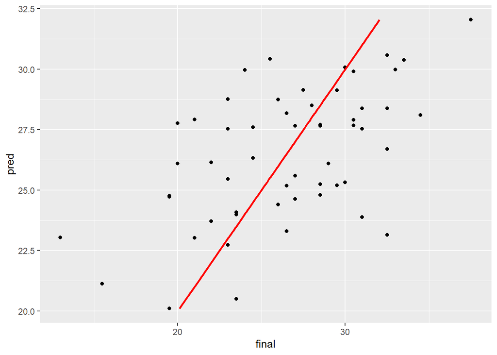

```r
loadPkg("ggplot2")
ggplot(df.with.predfin.from.model,aes(final,pred))+geom_point(aes(final,pred))+geom_line(aes(pred), colour="red", size=1)
```

```r
# We can also add the residuals
df.with.predfin.from.model <- add_residuals(df.with.predfin.from.model,model.final)
head(df.with.predfin.from.model)
```

```
##   midterm final   hw total pred resid
## 1    24.5  26.0 28.5  79.0 28.7 -2.74
## 2    22.5  24.5 28.2  75.2 27.6 -3.10
## 3    23.5  26.5 28.3  78.3 28.2 -1.67
## 4    23.5  34.5 29.2  87.2 28.1  6.40
## 5    22.5  30.5 27.3  80.3 27.7  2.83
## 6    16.0  31.0 27.5  74.5 23.9  7.12
```

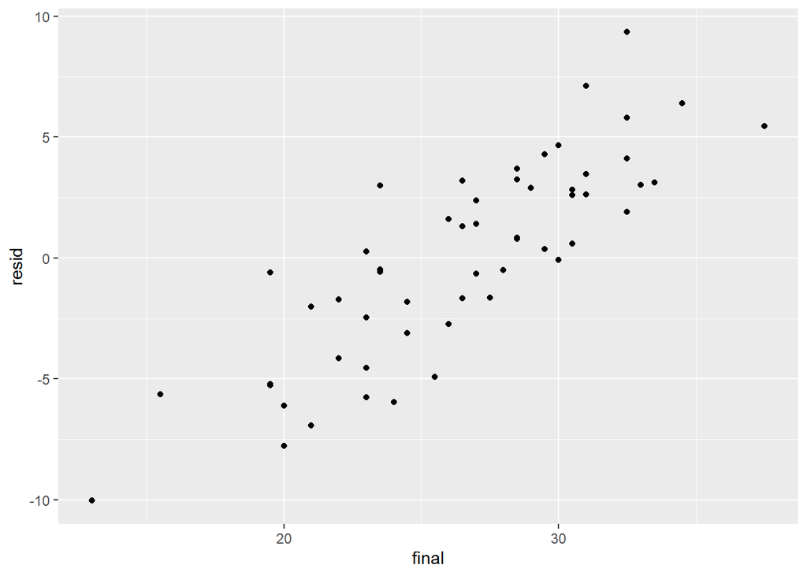

```r
# ggplot(df.with.predfin.from.model, aes(resid))+geom_freqpoly(binwidth=.05)
ggplot(df.with.predfin.from.model,aes(final,resid))+geom_point(aes(final,resid))
```

We can also use a few simple functions from the broom package

```r
loadPkg("broom")
#tidy will create a dataframe of our results
tidyfinal <-  tidy(model.final)
tidyfinal
```

```
## # A tibble: 3 x 5
##   term        estimate std.error statistic   p.value
##   <chr>          <dbl>     <dbl>     <dbl>     <dbl>
## 1 (Intercept)  16.8        4.08      4.12  0.000137
## 2 midterm       0.582      0.124     4.67  0.0000212
## 3 hw           -0.0816     0.149    -0.547 0.587
```

```r
#augment will add the model output
Model_Summary <- augment(model.final)
str(Model_Summary)
```

```
## tibble [55 x 9] (S3: tbl_df/tbl/data.frame)
##  $ final     : num [1:55] 26 24.5 26.5 34.5 30.5 31 33.5 31 29.5 37.5 ...
##  $ midterm   : num [1:55] 24.5 22.5 23.5 23.5 22.5 16 27.5 22.5 25 30 ...
##  $ hw        : num [1:55] 28.5 28.2 28.3 29.2 27.3 27.5 29.7 29 27.3 27.2 ...
##  $ .fitted   : num [1:55] 28.7 27.6 28.2 28.1 27.7 ...
##  $ .resid    : num [1:55] -2.74 -3.1 -1.67 6.4 2.83 ...
##  $ .hat      : num [1:55] 0.0344 0.0247 0.0286 0.0326 0.0224 ...
##  $ .sigma    : num [1:55] 4.24 4.24 4.25 4.16 4.24 ...
##  $ .cooksd   : num [1:55] 0.00518 0.00467 0.00159 0.02668 0.00351 ...
##  $ .std.resid: num [1:55] -0.661 -0.744 -0.403 1.542 0.677 ...
##  - attr(*, "terms")=Classes 'terms', 'formula'  language final ~ midterm + hw
##   .. ..- attr(*, "variables")= language list(final, midterm, hw)
##   .. ..- attr(*, "factors")= int [1:3, 1:2] 0 1 0 0 0 1
##   .. .. ..- attr(*, "dimnames")=List of 2
##   .. .. .. ..$ : chr [1:3] "final" "midterm" "hw"
##   .. .. .. ..$ : chr [1:2] "midterm" "hw"
##   .. ..- attr(*, "term.labels")= chr [1:2] "midterm" "hw"
##   .. ..- attr(*, "order")= int [1:2] 1 1
##   .. ..- attr(*, "intercept")= int 1
##   .. ..- attr(*, "response")= int 1
##   .. ..- attr(*, ".Environment")=<environment: R_GlobalEnv>
##   .. ..- attr(*, "predvars")= language list(final, midterm, hw)
##   .. ..- attr(*, "dataClasses")= Named chr [1:3] "numeric" "numeric" "numeric"
##   .. .. ..- attr(*, "names")= chr [1:3] "final" "midterm" "hw"
```

```r
head(Model_Summary)
```

```
## # A tibble: 6 x 9
##   final midterm    hw .fitted .resid   .hat .sigma .cooksd .std.resid
##   <dbl>   <dbl> <dbl>   <dbl>  <dbl>  <dbl>  <dbl>   <dbl>      <dbl>
## 1  26      24.5  28.5    28.7  -2.74 0.0344   4.24 0.00518     -0.661
## 2  24.5    22.5  28.2    27.6  -3.10 0.0247   4.24 0.00467     -0.744
## 3  26.5    23.5  28.3    28.2  -1.67 0.0286   4.25 0.00159     -0.403
## 4  34.5    23.5  29.2    28.1   6.40 0.0326   4.16 0.0267       1.54
## 5  30.5    22.5  27.3    27.7   2.83 0.0224   4.24 0.00351      0.677
## 6  31      16    27.5    23.9   7.12 0.0394   4.14 0.0406       1.72
```

We can also use the formula with predict, to well predict future values (according to th e linear model)

```r
loadPkg("stats")
predict(model.final,data.frame(midterm=c(25,52,78),hw=c(20,80,45)))
```

```
##    1    2    3
## 29.7 40.5 58.5
```

## MtCars Dataset

Next, let us look at the mtcars (Motor Cars) dataset.

### Variance Inflation Factor VIF

The Variance Inflation Factor VIF is a measure about how good/bad two regressors (*x*-variables) are correlated to others. The definition for the vif of a variable $k$ is given by  
vif<sub>k</sub> $= \frac{1}{1-R^2_k}$  
where $R^2_k$ is the coefficient of determination for the variable $k$.

Typically, the rule of thumb is:  
Perfect : vif = 1  
Great : 1 < vif < 5  
Okay : 5 < vif < 10  
Reject : vif > 10

There are different libraries equipped with the vif function, such as `faraway`, `rms`, and `car`. The last one `car::vif( )` requires two or more variables in the models, otherwise an error occurs. Of course, if only 1 variable, the result is trivial (always 1) to begin with.

Use the `ezids::xkablevif( )` function (with a model-object as the argument of the function) to display the vif values.

### Correlation Matrix

```r
summary(mtcars)
```

```
##       mpg            cyl            disp           hp           drat
##  Min.   :10.4   Min.   :4.00   Min.   : 71   Min.   : 52   Min.   :2.76
##  1st Qu.:15.4   1st Qu.:4.00   1st Qu.:121   1st Qu.: 96   1st Qu.:3.08
##  Median :19.2   Median :6.00   Median :196   Median :123   Median :3.69
##  Mean   :20.1   Mean   :6.19   Mean   :231   Mean   :147   Mean   :3.60
##  3rd Qu.:22.8   3rd Qu.:8.00   3rd Qu.:326   3rd Qu.:180   3rd Qu.:3.92
##  Max.   :33.9   Max.   :8.00   Max.   :472   Max.   :335   Max.   :4.93
##        wt            qsec            vs              am             gear
##  Min.   :1.51   Min.   :14.5   Min.   :0.000   Min.   :0.000   Min.   :3.00
##  1st Qu.:2.58   1st Qu.:16.9   1st Qu.:0.000   1st Qu.:0.000   1st Qu.:3.00
##  Median :3.33   Median :17.7   Median :0.000   Median :0.000   Median :4.00
##  Mean   :3.22   Mean   :17.9   Mean   :0.438   Mean   :0.406   Mean   :3.69
##  3rd Qu.:3.61   3rd Qu.:18.9   3rd Qu.:1.000   3rd Qu.:1.000   3rd Qu.:4.00
##  Max.   :5.42   Max.   :22.9   Max.   :1.000   Max.   :1.000   Max.   :5.00
##       carb
##  Min.   :1.00
##  1st Qu.:2.00
##  Median :2.00
##  Mean   :2.81
##  3rd Qu.:4.00
##  Max.   :8.00
```

```r
str(mtcars)
```

```
## 'data.frame':    32 obs. of  11 variables:
##  $ mpg : num  21 21 22.8 21.4 18.7 18.1 14.3 24.4 22.8 19.2 ...
##  $ cyl : num  6 6 4 6 8 6 8 4 4 6 ...
##  $ disp: num  160 160 108 258 360 ...
##  $ hp  : num  110 110 93 110 175 105 245 62 95 123 ...
##  $ drat: num  3.9 3.9 3.85 3.08 3.15 2.76 3.21 3.69 3.92 3.92 ...
##  $ wt  : num  2.62 2.88 2.32 3.21 3.44 ...
##  $ qsec: num  16.5 17 18.6 19.4 17 ...
##  $ vs  : num  0 0 1 1 0 1 0 1 1 1 ...
##  $ am  : num  1 1 1 0 0 0 0 0 0 0 ...
##  $ gear: num  4 4 4 3 3 3 3 4 4 4 ...
##  $ carb: num  4 4 1 1 2 1 4 2 2 4 ...
```

```r
head(mtcars)
```

```
##                    mpg cyl disp  hp drat   wt qsec vs am gear carb
## Mazda RX4         21.0   6  160 110 3.90 2.62 16.5  0  1    4    4
## Mazda RX4 Wag     21.0   6  160 110 3.90 2.88 17.0  0  1    4    4
## Datsun 710        22.8   4  108  93 3.85 2.32 18.6  1  1    4    1
## Hornet 4 Drive    21.4   6  258 110 3.08 3.21 19.4  1  0    3    1
## Hornet Sportabout 18.7   8  360 175 3.15 3.44 17.0  0  0    3    2
## Valiant           18.1   6  225 105 2.76 3.46 20.2  1  0    3    1
```

```r
mtcarscor = cor(mtcars) # get the correlation matrix between all numerical variables.
mtcarscor
```

```
##         mpg    cyl   disp     hp    drat     wt    qsec     vs      am   gear
## mpg   1.000 -0.852 -0.848 -0.776  0.6812 -0.868  0.4187  0.664  0.5998  0.480
## cyl  -0.852  1.000  0.902  0.832 -0.6999  0.782 -0.5912 -0.811 -0.5226 -0.493
## disp -0.848  0.902  1.000  0.791 -0.7102  0.888 -0.4337 -0.710 -0.5912 -0.556
## hp   -0.776  0.832  0.791  1.000 -0.4488  0.659 -0.7082 -0.723 -0.2432 -0.126
## drat  0.681 -0.700 -0.710 -0.449  1.0000 -0.712  0.0912  0.440  0.7127  0.700
## wt   -0.868  0.782  0.888  0.659 -0.7124  1.000 -0.1747 -0.555 -0.6925 -0.583
## qsec  0.419 -0.591 -0.434 -0.708  0.0912 -0.175  1.0000  0.745 -0.2299 -0.213
## vs    0.664 -0.811 -0.710 -0.723  0.4403 -0.555  0.7445  1.000  0.1683  0.206
## am    0.600 -0.523 -0.591 -0.243  0.7127 -0.692 -0.2299  0.168  1.0000  0.794
## gear  0.480 -0.493 -0.556 -0.126  0.6996 -0.583 -0.2127  0.206  0.7941  1.000
## carb -0.551  0.527  0.395  0.750 -0.0908  0.428 -0.6562 -0.570  0.0575  0.274
##         carb
## mpg  -0.5509
## cyl   0.5270
## disp  0.3950
## hp    0.7498
## drat -0.0908
## wt    0.4276
## qsec -0.6562
## vs   -0.5696
## am    0.0575
## gear  0.2741
## carb  1.0000
```

```r
xkabledply(mtcarscor)
```

Table

|  | mpg | cyl | disp | hp | drat | wt | qsec | vs | am | gear | carb |
| --- | --- | --- | --- | --- | --- | --- | --- | --- | --- | --- | --- |
| mpg | 1.000 | -0.852 | -0.848 | -0.776 | 0.6812 | -0.868 | 0.4187 | 0.664 | 0.5998 | 0.480 | -0.5509 |
| cyl | -0.852 | 1.000 | 0.902 | 0.832 | -0.6999 | 0.782 | -0.5912 | -0.811 | -0.5226 | -0.493 | 0.5270 |
| disp | -0.848 | 0.902 | 1.000 | 0.791 | -0.7102 | 0.888 | -0.4337 | -0.710 | -0.5912 | -0.556 | 0.3950 |
| hp | -0.776 | 0.832 | 0.791 | 1.000 | -0.4488 | 0.659 | -0.7082 | -0.723 | -0.2432 | -0.126 | 0.7498 |
| drat | 0.681 | -0.700 | -0.710 | -0.449 | 1.0000 | -0.712 | 0.0912 | 0.440 | 0.7127 | 0.700 | -0.0908 |
| wt | -0.868 | 0.782 | 0.888 | 0.659 | -0.7124 | 1.000 | -0.1747 | -0.555 | -0.6925 | -0.583 | 0.4276 |
| qsec | 0.419 | -0.591 | -0.434 | -0.708 | 0.0912 | -0.175 | 1.0000 | 0.745 | -0.2299 | -0.213 | -0.6562 |
| vs | 0.664 | -0.811 | -0.710 | -0.723 | 0.4403 | -0.555 | 0.7445 | 1.000 | 0.1683 | 0.206 | -0.5696 |
| am | 0.600 | -0.523 | -0.591 | -0.243 | 0.7127 | -0.692 | -0.2299 | 0.168 | 1.0000 | 0.794 | 0.0575 |
| gear | 0.480 | -0.493 | -0.556 | -0.126 | 0.6996 | -0.583 | -0.2127 | 0.206 | 0.7941 | 1.000 | 0.2741 |
| carb | -0.551 | 0.527 | 0.395 | 0.750 | -0.0908 | 0.428 | -0.6562 | -0.570 | 0.0575 | 0.274 | 1.0000 |

The correlation matrix is hard to read, especially for too many variables. We can use some other packages to help. First, we can try the library `corrplot`.

```r
loadPkg("corrplot")
```

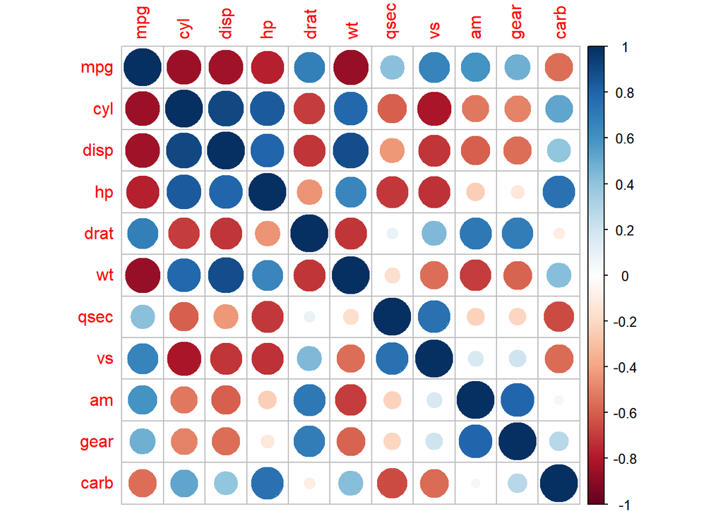

```r
corrplot(mtcarscor)
```

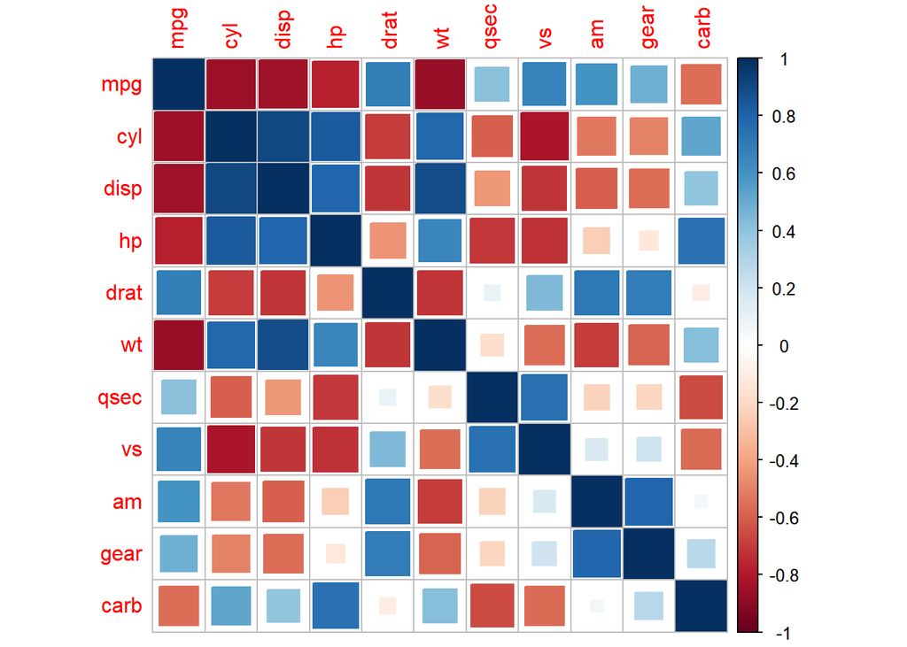

```r
corrplot(mtcarscor, method = "square") # try "circle", "square", "ellipse", "number", "shade", "color", "pie"
```

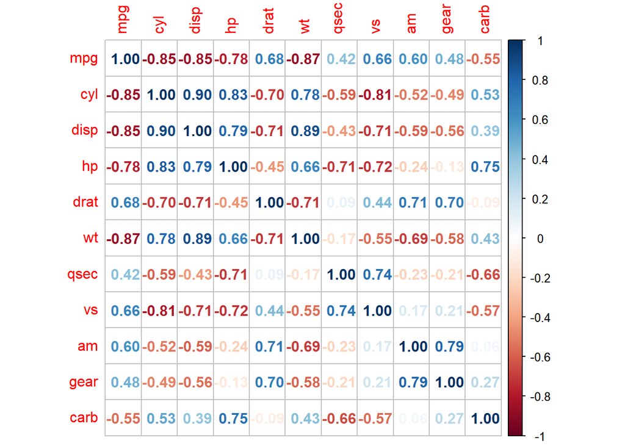

```r
corrplot(mtcarscor, method = "number")
```

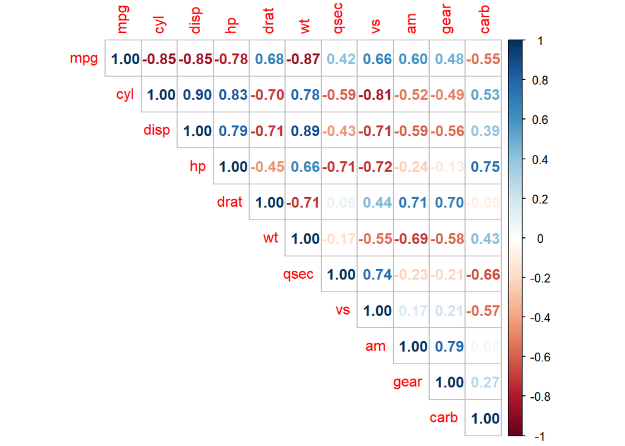

```r
corrplot(mtcarscor, method = "number", type="upper")
```

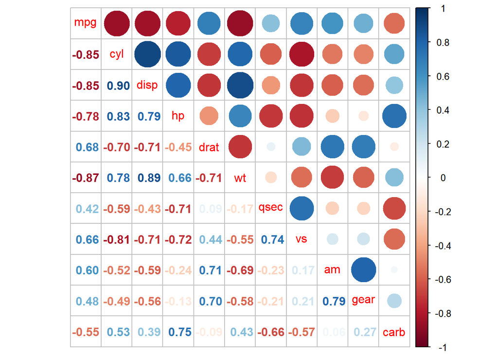

```r
corrplot.mixed(mtcarscor)
```

We can also use the library `lattice` to help see these correlations…

```r
loadPkg("lattice") # lattice and ggplot2 combined allow us to use the "pairs" function below
```

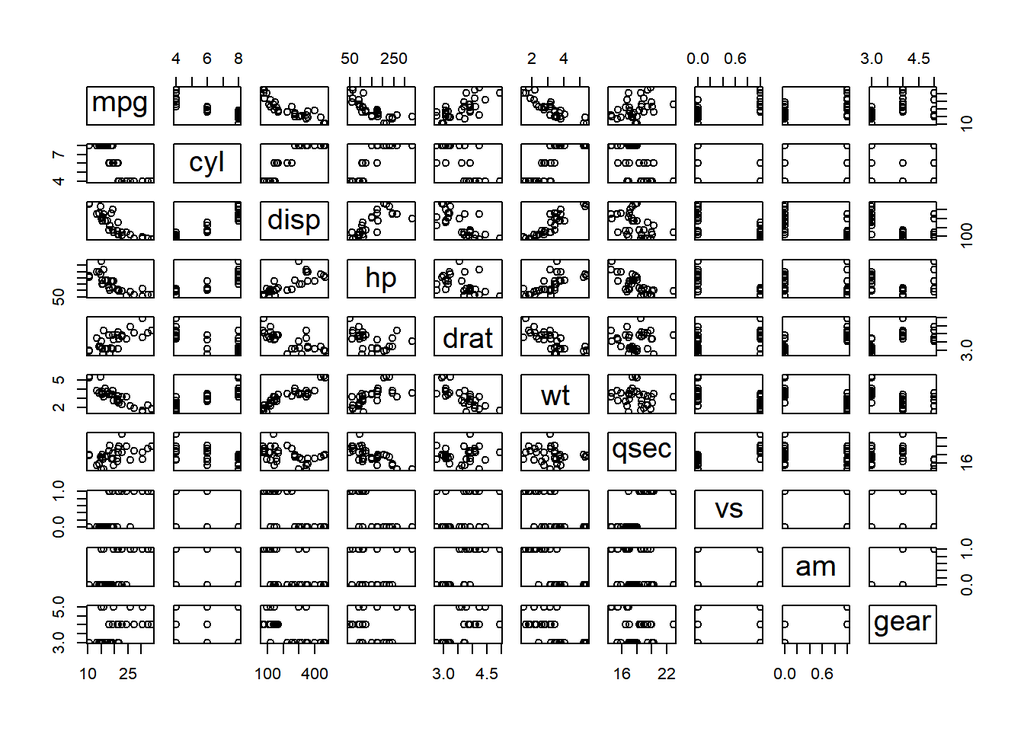

```r
pairs(mtcars[1:10])
```

So now, let us see if we can try to build a model to predict the mpg (miles per gallon) of a vehicle. (Results hidden in html.)

```r
fit1 <- lm(mpg ~ wt, data = mtcars)
summary(fit1)
```

```
##
## Call:
## lm(formula = mpg ~ wt, data = mtcars)
##
## Residuals:
##    Min     1Q Median     3Q    Max
## -4.543 -2.365 -0.125  1.410  6.873
##
## Coefficients:
##             Estimate Std. Error t value Pr(>|t|)
## (Intercept)   37.285      1.878   19.86  < 2e-16 ***
## wt            -5.344      0.559   -9.56  1.3e-10 ***
## ---
## Signif. codes:  0 '***' 0.001 '**' 0.01 '*' 0.05 '.' 0.1 ' ' 1
##
## Residual standard error: 3.05 on 30 degrees of freedom
## Multiple R-squared:  0.753,  Adjusted R-squared:  0.745
## F-statistic: 91.4 on 1 and 30 DF,  p-value: 1.29e-10
```

```r
# vif(fit1)
```

Use the `xkabledply( )` function to display it.

```r
xkabledply(fit1, title = paste("Model :", format(formula(fit1)) ) )
```

Model : mpg ~ wt

|  | Estimate | Std. Error | t value | Pr(>\|t\|) |
| --- | --- | --- | --- | --- |
| (Intercept) | 37.29 | 1.878 | 19.86 | 0 |
| wt | -5.34 | 0.559 | -9.56 | 0 |

A standard plot function gives us a bunch of plots.

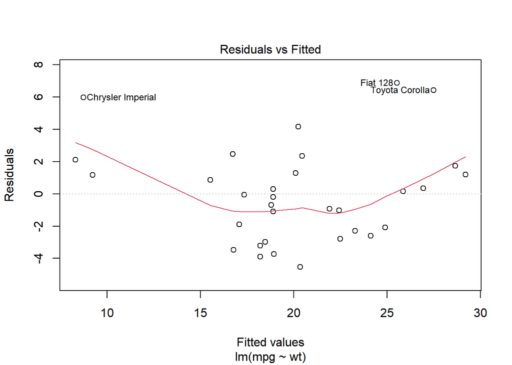

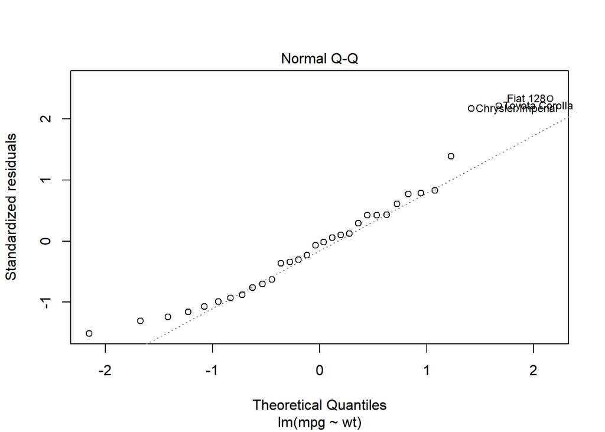

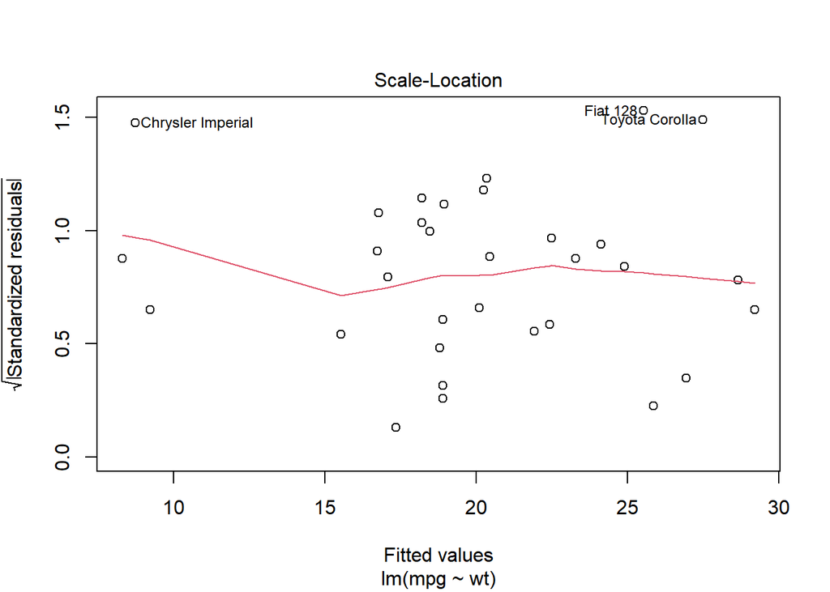

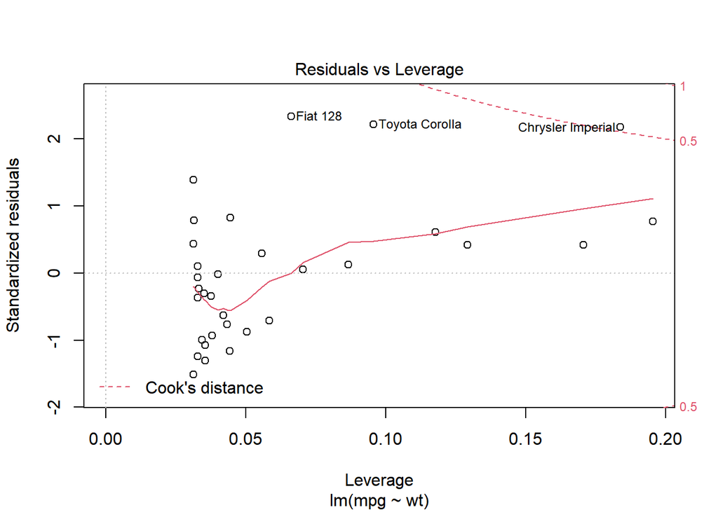

```r
plot(fit1)
```

We can also check the correlation test between the two variables, essentially checking whether the confidence interval of the correlation r is including zero. (I have not found a better way to display the `cor.test` results.)

```r
cor.test(mtcars$mpg, mtcars$wt) -> cortest
cortest
```

```
##
##  Pearson's product-moment correlation
##
## data:  mtcars$mpg and mtcars$wt
## t = -10, df = 30, p-value = 1e-10
## alternative hypothesis: true correlation is not equal to 0
## 95 percent confidence interval:
##  -0.934 -0.744
## sample estimates:
##    cor
## -0.868
```

```r
fit2 <- lm(mpg ~ wt+disp, data = mtcars)
xkabledply(fit2, title = paste("Model :", format(formula(fit2)) ) )
```

Model : mpg ~ wt + disp

|  | Estimate | Std. Error | t value | Pr(>\|t\|) |
| --- | --- | --- | --- | --- |
| (Intercept) | 34.9606 | 2.1645 | 16.15 | 0.0000 |
| wt | -3.3508 | 1.1641 | -2.88 | 0.0074 |
| disp | -0.0177 | 0.0092 | -1.93 | 0.0636 |

```r
xkablevif(fit2)
```

VIFs of the model

| disp | wt |
| --- | --- |
| 4.73 | 4.73 |

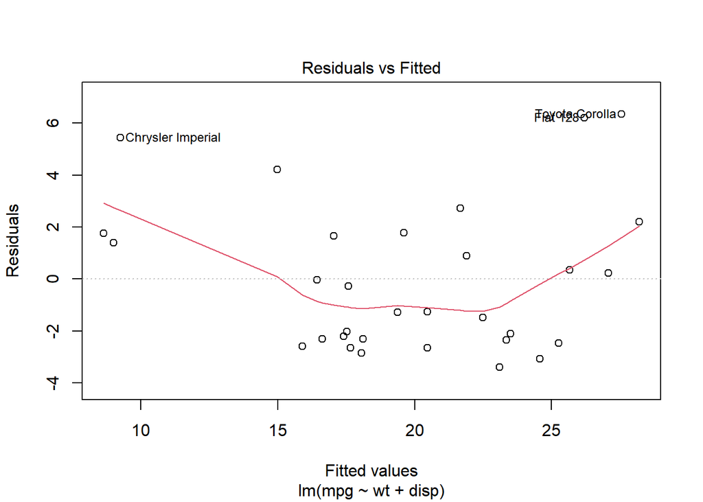

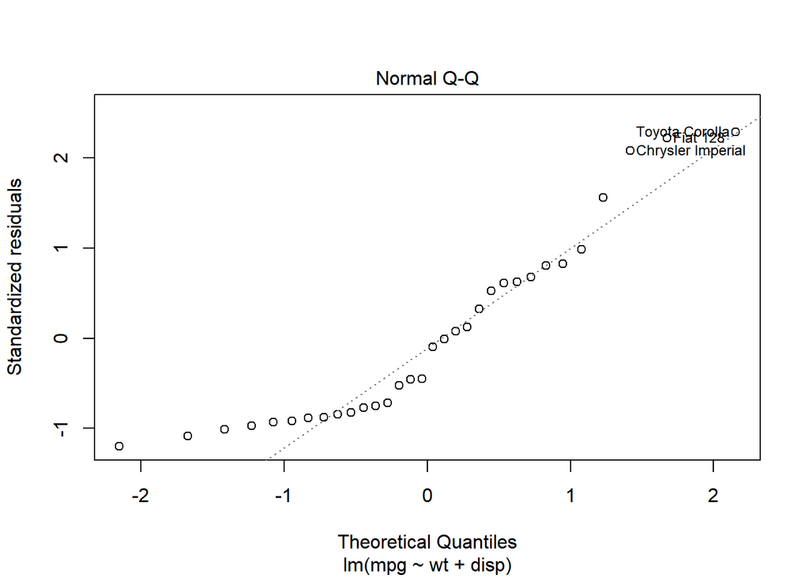

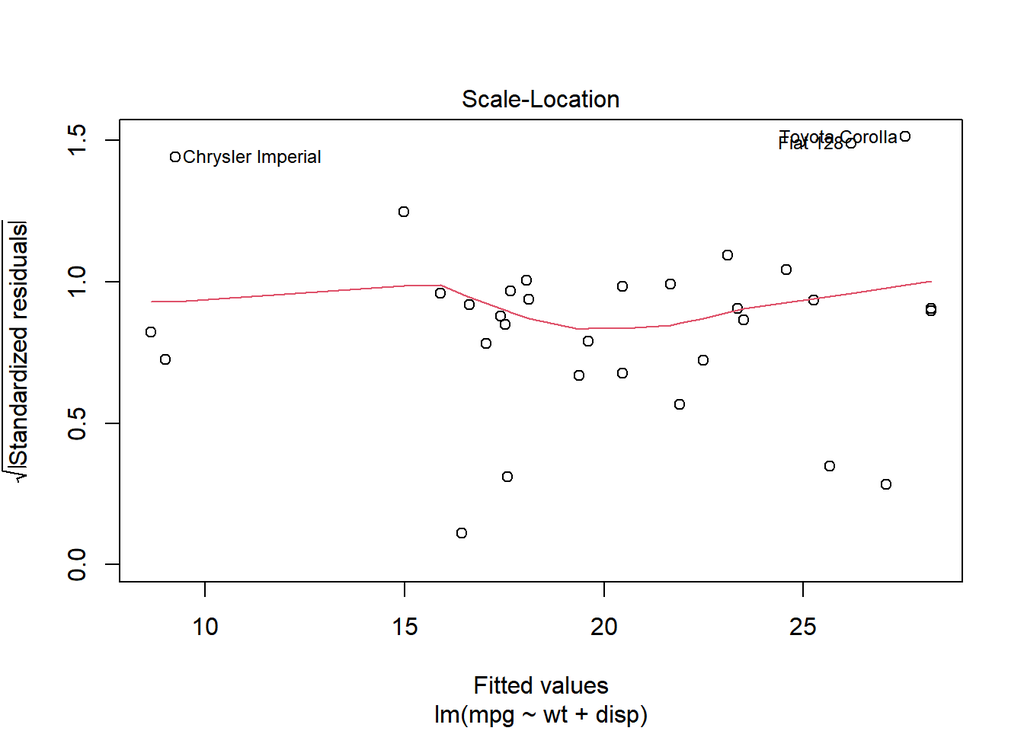

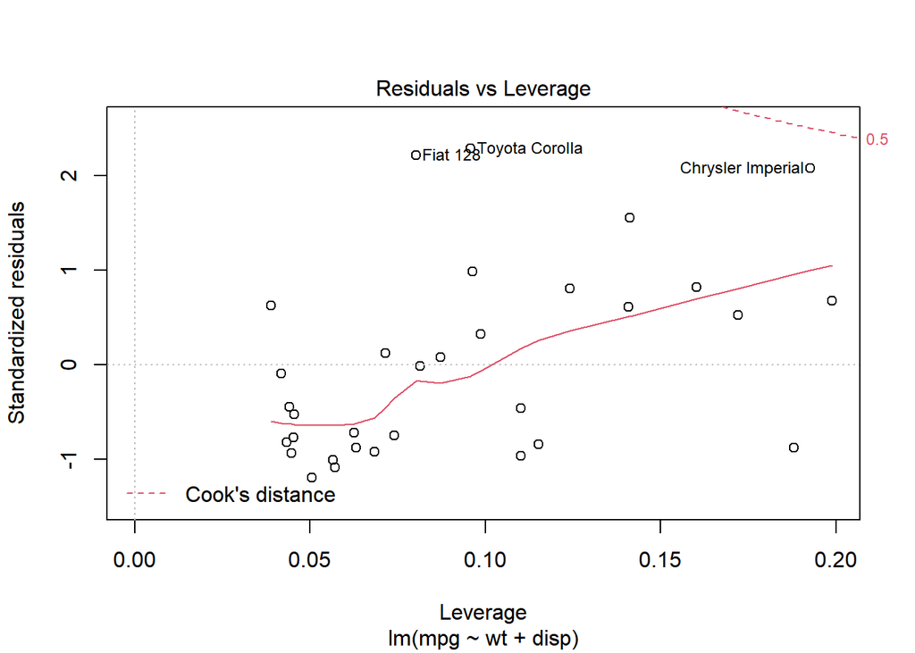

```r
plot(fit2)
```

```r
fit3 <- lm(mpg ~ wt+disp+cyl, data = mtcars)
xkabledply(fit3, title = paste("Model :", format(formula(fit3)) ) )
```

Model : mpg ~ wt + disp + cyl

|  | Estimate | Std. Error | t value | Pr(>\|t\|) |
| --- | --- | --- | --- | --- |
| (Intercept) | 41.1077 | 2.8424 | 14.462 | 0.0000 |
| wt | -3.6357 | 1.0401 | -3.495 | 0.0016 |
| disp | 0.0075 | 0.0118 | 0.631 | 0.5332 |
| cyl | -1.7849 | 0.6071 | -2.940 | 0.0065 |

```r
xkablevif(fit3)
```

VIFs of the model

[output not shown]

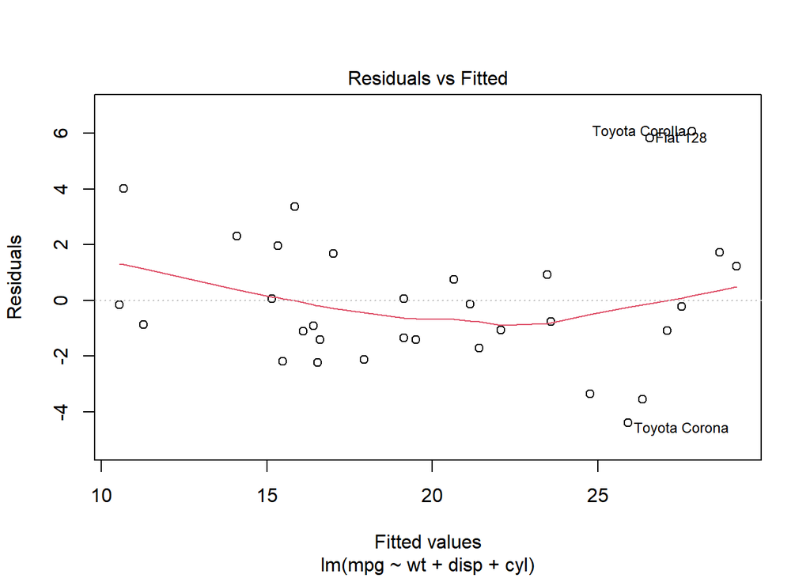

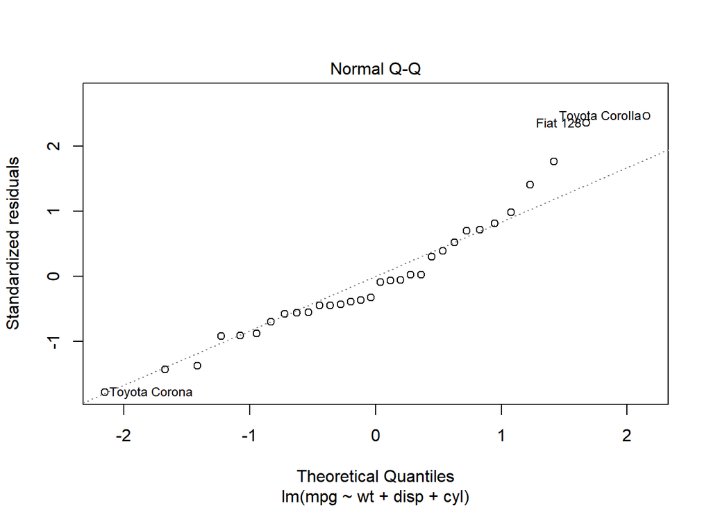

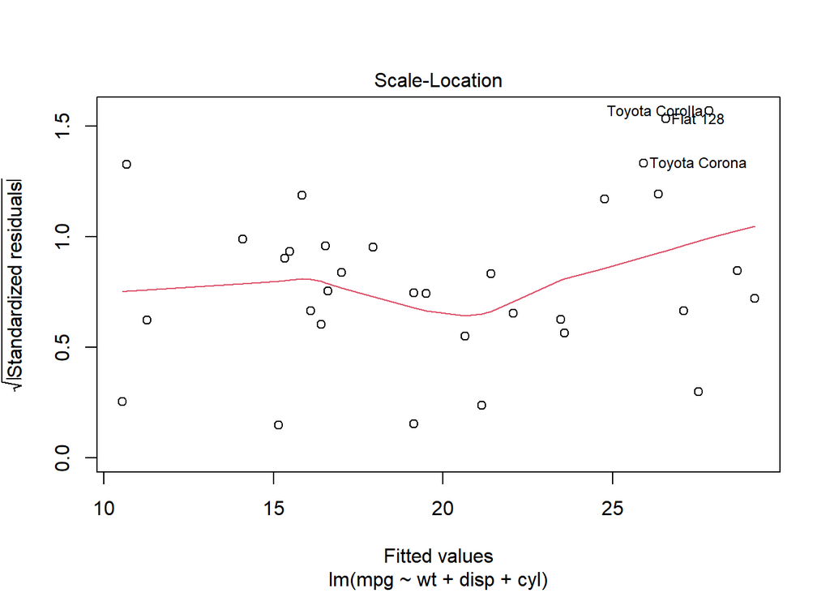

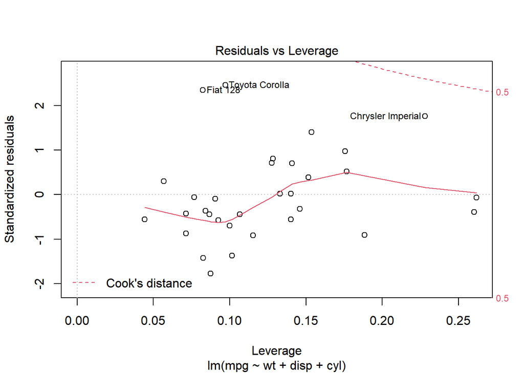

```r
plot(fit3)
```

```r
fit4 <- lm(mpg ~ wt+disp+cyl+hp, data = mtcars)
xkabledply(fit4, title = paste("Model :", format(formula(fit4)) ) )
```

Model : mpg ~ wt + disp + cyl + hp

|  | Estimate | Std. Error | t value | Pr(>\|t\|) |
| --- | --- | --- | --- | --- |
| (Intercept) | 40.8285 | 2.7575 | 14.806 | 0.0000 |
| wt | -3.8539 | 1.0155 | -3.795 | 0.0008 |
| disp | 0.0116 | 0.0117 | 0.989 | 0.3314 |
| cyl | -1.2933 | 0.6559 | -1.972 | 0.0589 |
| hp | -0.0205 | 0.0121 | -1.691 | 0.1024 |

```r
xkablevif(fit4)
```

VIFs of the model

[output not shown]

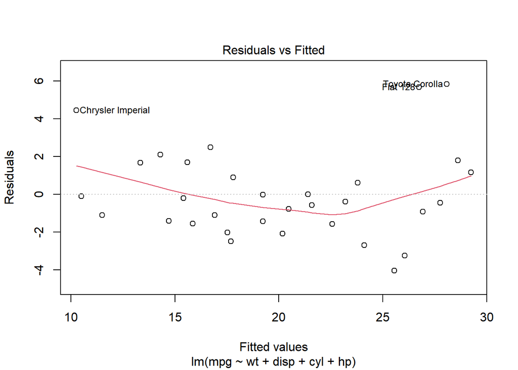

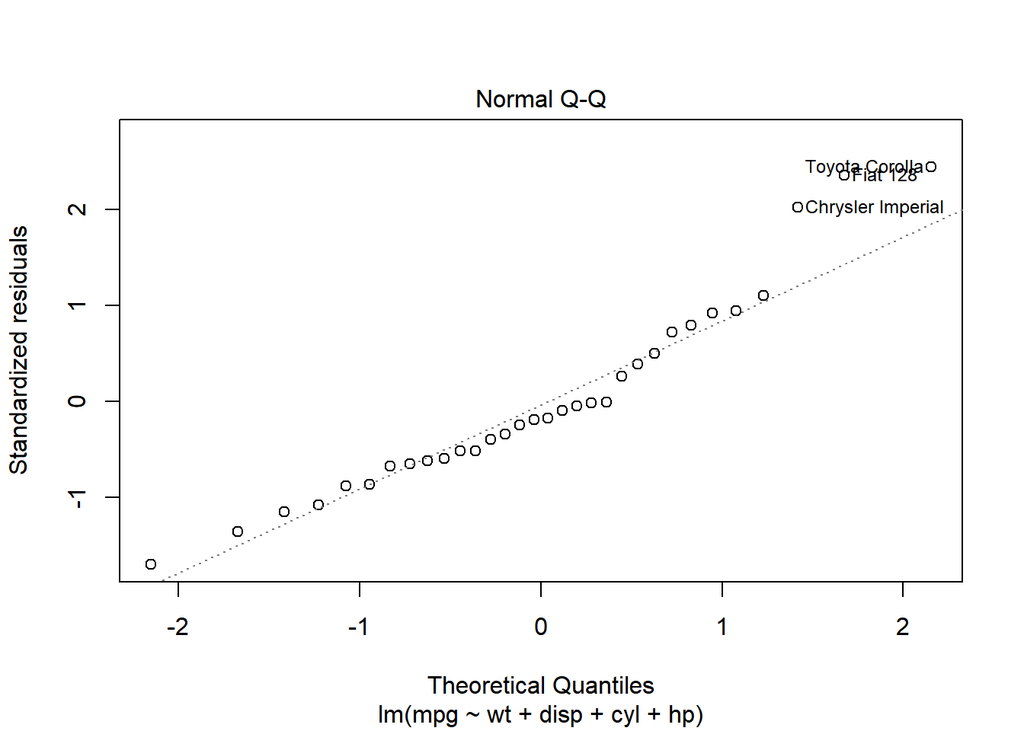

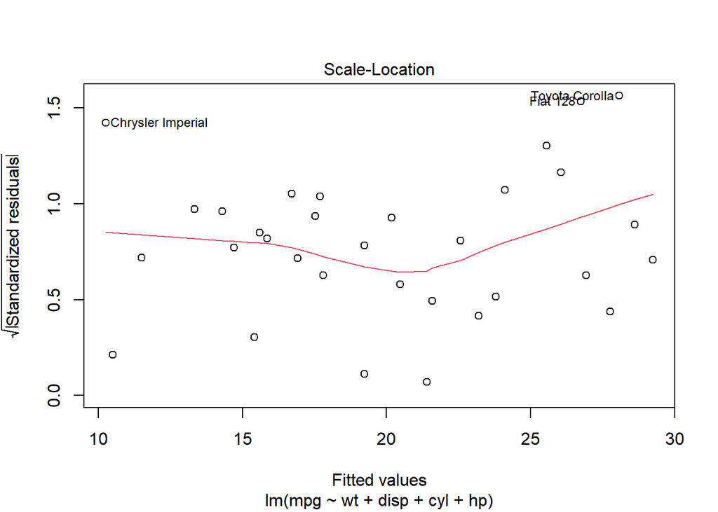

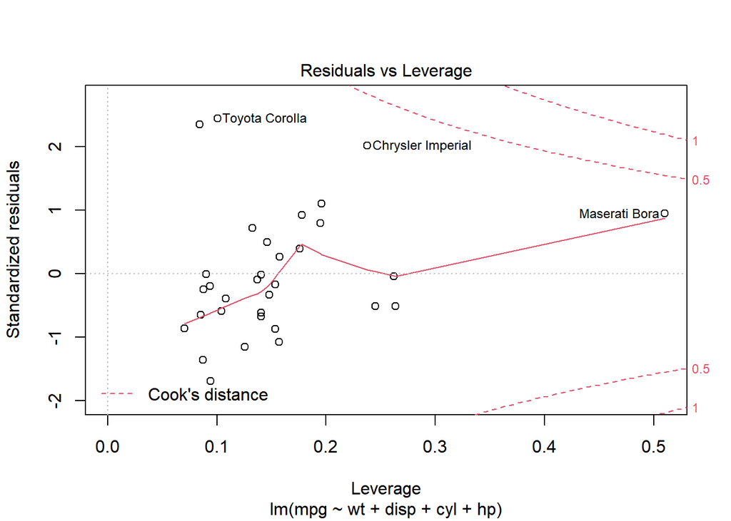

```r
plot(fit4)
```

### Summary of the four LMs

We can summarize the results here. (Also see the contrast between the first two rows where I used the default r<sup>2</sup> in markdown, and $r^2$ with $\LaTeX$.)

[output not shown]

We learned how to use ANOVA to test mean values (quantitative variable) of different samples. We can actually also use ANOVA to compare linear models. Notice that the R function `aov()` internally calls the `lm()` function, and produces a model. If you look at the object created by `aov()`, it has a `lm()` model object part. We can then use the function `anova()` (both `aov()` and `anova()` are in the R stats library) to analyse the models. (Run the code block locally to see the results.)

```r
anova(fit1,fit2,fit3,fit4) -> anovaRes
anovaRes
```

```
## Analysis of Variance Table
##
## Model 1: mpg ~ wt
## Model 2: mpg ~ wt + disp
## Model 3: mpg ~ wt + disp + cyl
## Model 4: mpg ~ wt + disp + cyl + hp
##   Res.Df RSS Df Sum of Sq    F Pr(>F)
## 1     30 278
## 2     29 247  1      31.6 5.01 0.0336 *
## 3     28 188  1      58.2 9.22 0.0053 **
## 4     27 170  1      18.0 2.86 0.1024
## ---
## Signif. codes:  0 '***' 0.001 '**' 0.01 '*' 0.05 '.' 0.1 ' ' 1
```

```r
str(anovaRes)
```

```
## Classes 'anova' and 'data.frame':    4 obs. of  6 variables:
##  $ Res.Df   : num  30 29 28 27
##  $ RSS      : num  278 247 188 170
##  $ Df       : num  NA 1 1 1
##  $ Sum of Sq: num  NA 31.6 58.2 18
##  $ F        : num  NA 5.01 9.22 2.86
##  $ Pr(>F)   : num  NA 0.03361 0.00526 0.10238
##  - attr(*, "heading")= chr [1:2] "Analysis of Variance Table\n" "Model 1: mpg ~ wt\nModel 2: mpg ~ wt + disp\nModel 3: mpg ~ wt + disp + cyl\nModel 4: mpg ~ wt + disp + cyl + hp"
```

The `anova( )` function returns an object that is essentially a table/dataframe. You can use the `xkabledply( )` function to display it.

```r
xkabledply(anovaRes, title = "ANOVA comparison between the models")
```

ANOVA comparison between the models

| Res.Df | RSS | Df | Sum of Sq | F | Pr(>F) |
| --- | --- | --- | --- | --- | --- |
| 30 | 278 | NA | NA | NA | NA |
| 29 | 247 | 1 | 31.6 | 5.01 | 0.0336 |
| 28 | 188 | 1 | 58.2 | 9.22 | 0.0053 |
| 27 | 170 | 1 | 18.0 | 2.86 | 0.1024 |

The table shows the step-by-step Residual DF, Residual SS, as well as *REDUCTION* in DF and Sum of Sq. The last two columns show the F-Statistics and p-values of the anova test (between the current and previous rows).